# Linear regression

*In the following, we will explore, with a rough explanatory and predictive model,* *the association that approaches and study skills to learning as well as attitudes towards* *statistics has on exam performance in statistics. The explanatory variables concerning* *approaches to studying and study skills are based on a shortened version of a standardized* *measure called ASSIST (Approaches and Study Skills Inventory for Students) and the* *explanatory variables concerning attitudes towards statistics are based on SATS* *(Survey of Attitudes Toward Statistics). We construct composite measures on the attitude,* *a deep approach to learning, a surface approach to learning and a strategic approach to* *learning that are based on the mean of original questionnaire items on each of these* *dimensions. We will treat our integer valued target variable as if it were continuouns* *and use a linear regression model to explain and predict the score with these dimensions.*

```
## [1] "Thu Nov 09 09:54:06 2023"
```

We first read in an analysis dataset we have already preprocessed.

```r
# We require the library readr

library(readr)

# Read the file into the workspace
learning2014<-read_csv("~/Intro_to_ODS/IODS/data/learning2014.csv")
# Check the head and structure of the data
str(learning2014)
```

```
## spec_tbl_df [166 x 7] (S3: spec_tbl_df/tbl_df/tbl/data.frame)
##  $ gender  : chr [1:166] "F" "M" "F" "M" ...
##  $ age     : num [1:166] 53 55 49 53 49 38 50 37 37 42 ...
##  $ attitude: num [1:166] 3.7 3.1 2.5 3.5 3.7 3.8 3.5 2.9 3.8 2.1 ...
##  $ deep    : num [1:166] 3.58 2.92 3.5 3.5 3.67 ...
##  $ stra    : num [1:166] 3.38 2.75 3.62 3.12 3.62 ...
##  $ surf    : num [1:166] 2.58 3.17 2.25 2.25 2.83 ...
##  $ points  : num [1:166] 25 12 24 10 22 21 21 31 24 26 ...
##  - attr(*, "spec")=
##   .. cols(
##   ..   gender = col_character(),
##   ..   age = col_double(),
##   ..   attitude = col_double(),
##   ..   deep = col_double(),
##   ..   stra = col_double(),
##   ..   surf = col_double(),
##   ..   points = col_double()
##   .. )
##  - attr(*, "problems")=<externalptr>
```

```r
head(learning2014)
```

```
## # A tibble: 6 x 7
##   gender   age attitude  deep  stra  surf points
##   <chr>  <dbl>    <dbl> <dbl> <dbl> <dbl>  <dbl>
## 1 F         53      3.7  3.58  3.38  2.58     25
## 2 M         55      3.1  2.92  2.75  3.17     12
## 3 F         49      2.5  3.5   3.62  2.25     24
## 4 M         53      3.5  3.5   3.12  2.25     10
## 5 M         49      3.7  3.67  3.62  2.83     22
## 6 F         38      3.8  4.75  3.62  2.42     21
```

The data has 166 observations on 7 variables: “gender”, “age”, “attitude”, “deep”, “stra”, “surf” and “points”. Gender is a character vector that is a categorical variable and the others are numeric, with age and points integer-valued (absolute scale) and the rest interval-scaled (the interpretation being that there is no natural 0 for attitude nor the approaches to learning). “Attitude”, “deep”, “stra” and “surf” are composite measures on attitudes towards statistics, deep, strategic and surface approach to learning, respectively. “Points” is our primary outcome variable of interest that measures the score on a statistics exam.

Let us take a brief look at the data with a quick visual.

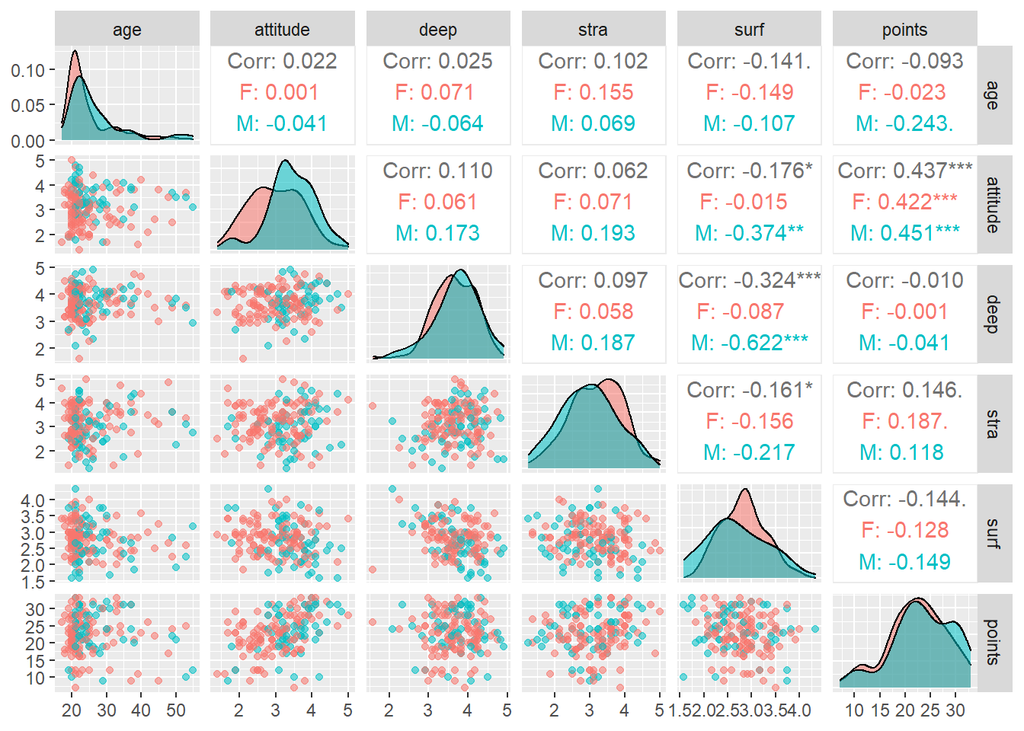

```r
# We require GGally and ggplot2 libraries for our visuals
library(GGally)
library(ggplot2)

# Create a plot matrix with ggpairs()
p <- ggpairs(learning2014[-1], mapping = aes(col=learning2014$gender, alpha=0.3), lower = list(combo = wrap("facethist", bins = 20)))

# draw the plot
p
```

```r
# we observe that the transparency changes (the novel colors are more transparent)
```